# Sample Size Calculation

Prof A Pathmeswaran  
pathmes@kln.ac.lk  
2022-08-30

## Outline

1. Background
2. Basics
3. Common situations

## Why do it?

1. Researcher
   - Ensure useful results
   - Plan logistics
2. Higher degree committees
   - Assess feasibility
   - Usefulness of results
3. Funding agency
   - Value for money

## Based on the research question

- Research questions/ objective
  1. Estimate a mean or percentage with a given precision - descriptive study.
  2. Identify the association between two variables/ difference between two groups - testing a hypothesis or analytical study. Difference between two means, difference between two percentages, a correlation coefficient etc.

## Descriptive study

- Estimating population value based on sample findings
- Larger the sample size more precise estimate (narrower confidence interval)
- Larger the sample size higher confidence
- Higher the variability larger sample size
  - Numeric variable - standard deviation
  - Categorical variable - % closer to 50%

## Descriptive study - Numeric outcome

- Required information
  1. Acceptable difference (d) half the width of the 95% Confidence Interval
  2. An estimate of the standard deviation (sd)

N is the required sample size

$$N = \frac{1.96^2 * sd^2}{d^2}$$

## Descriptive study - Categorical outcome

- Required information
  1. Acceptable difference (d) half the width of the 95% Confidence Interval
  2. An estimate of the expected percentage (p)

N is the required sample size

$$N = \frac{1.96^2 * p(100-p)}{d^2}$$

## Analytical Study

- Avoid type I error (declaring as significant by mistake)
  - p < 0.05
  - p < 0.01
- Ensure adequate power (detecting an association if it is there)
  - 80%
  - 90%

## Analytical study - Numeric outcome

- Required information
  1. Expected difference/ effect size (d)
  2. Estimate of the two standard deviations (sd<sub>1</sub> and sd<sub>2</sub>)

*n* is the required sample size **per group** (significance 0.05 & power 80%).

$$n = \frac{(1.96 + 0.84)^2(sd_1^2 + sd_2^2)}{d^2}$$

If significance 0.01 & power 90%)
$$n = \frac{(2.58 + 1.28)^2(sd_1^2 + sd_2^2)}{d^2}$$

## Analytical study - Categorical outcome

- Required information
  1. Expected difference/ effect size (p<sub>1</sub> - p<sub>2</sub>)
  2. Estimate of the two percentages (p<sub>1</sub> and p<sub>2</sub>)

*n* is the required sample size **per group** (significance 0.05 & power 80%).

$$n = \frac{(1.96 + 0.84)^2[(p_1(100- p_1) + p_2(100-p_2)]}{(p_1 - p_2)^2}$$

## Sampling methods and sample size

- Modify calculation based on sampling method
  - Cluster samples result in larger standard errors
  - Unequal group sizes increase the total sample size

## What if the sample size is fixed?

- Secondary data
- Feasibility
- Cost

## Fixed sample size

- Indicate what is possible with that sample size
  - Expected confidence interval for a percentage
- Example
  - Available sample size is 1000
  - Expected 95% CI if the % is 1, 2.5, 5, 10, 25, 40 or 50

## Expected confidence intervals

| PointEst | Lower | Upper |
| --- | --- | --- |
| 1.0 | 0.5 | 1.8 |
| 2.5 | 1.7 | 3.7 |
| 5.0 | 3.8 | 6.5 |
| 10.0 | 8.3 | 12.0 |
| 25.0 | 22.4 | 27.8 |
| 40.0 | 37.0 | 43.1 |
| 50.0 | 46.9 | 53.1 |

## Fixed sample size

- Analytical study
  - Calculate expected power for different scenarios
- Example
  - Available sample size is 1000
  - Equal number of exposed & unexposed
  - % with outcome
  - 10 & 15
  - 10 & 20

## Expected power

| Size1 | Prev1 | Size2 | Prev2 | Power |
| --- | --- | --- | --- | --- |
| 500 | 10 | 500 | 15 | 63% |
| 500 | 10 | 500 | 20 | 96% |
| 900 | 10 | 100 | 20 | 81% |

[OpenEpi](https://www.openepi.com/Menu/OE_Menu.htm)

## Power and sample size

(Sig = 0.05, P<sub>1</sub> = 0.15 & p<sub>2</sub> = 0.1)

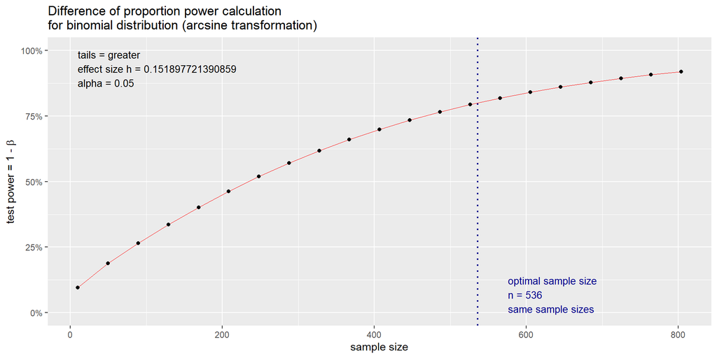

## Power and sample size

(Sig = 0.01, P<sub>1</sub> = 0.15 & p<sub>2</sub> = 0.1)

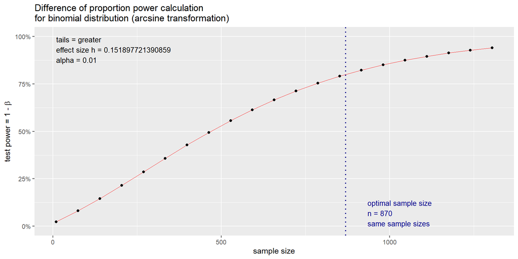

## Power and sample size

(P<sub>1</sub> = 0.5 & p<sub>2</sub> = 0.42)

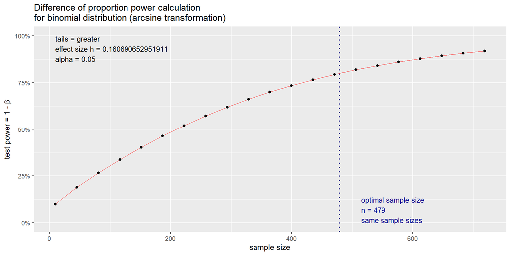

## Recap

- Background
  - Study designs
  - Standard error and confidence intervals
  - Significance and power
- Basic Sample size calculations
- Fixed sample size

[Home](https://pathmes.quarto.pub/sample-size-calculation/)